# Python Study

## 3rd_Study_Titanic Machine Learning from Disaster(2018.04.04)

## **개관**

입문자들에게 언제나 추천되는 **Titanic** 에 관한 데이터 분석 문제를 풀어보겠습니다.  
이 문제는 [케글](https://www.kaggle.com/) 에 기본문제로 등록되어 있습니다. 링크는 여기. https://www.kaggle.com/c/titanic

데이터분석 문제의 가장 큰 범주로 **Classification** 과 **Regression**이 있습니다.  
그 중에 이 **Titanic** 문제는 **Classification(분류)**를 하는 문제가 되겠습니다.

이 문제를 푸는데 있어서 아래와 같은 순서로 풀고자 하였습니다.

1. 데이터를 관찰하고
2. 데이터를 정제하고
3. 모형에 적용하여 정답 도출.

또 이 notebook 파일을 작성하는데에 아래의 kernel들을 적극적으로 참고하였습니다.

https://www.kaggle.com/datalana/the-preprocessing-framework-with-titanic  
https://www.kaggle.com/anshumank/titanic-survivor-prediction  
https://www.kaggle.com/athabascaai/titanic-passenger-graphs-for-feature-inspection

## 1. 페키지 Load, 데이터 Load

### 1.1 페키지 Load

```python
import numpy as np
import pandas as pd

import os

import matplotlib.pyplot as plt

from sklearn.ensemble import RandomForestClassifier
from sklearn.preprocessing import StandardScaler
from sklearn.metrics import confusion_matrix
```

### 1.2 데이터 Load

```python
train_df = pd.read_csv('train.csv')
test_df = pd.read_csv('test.csv')

train_df.head()
```

|  | PassengerId | Survived | Pclass | Name | Sex | Age | SibSp | Parch | Ticket | Fare | Cabin | Embarked |
| --- | --- | --- | --- | --- | --- | --- | --- | --- | --- | --- | --- | --- |
| 0 | 1 | 0 | 3 | Braund, Mr. Owen Harris | male | 22.0 | 1 | 0 | A/5 21171 | 7.2500 | NaN | S |
| 1 | 2 | 1 | 1 | Cumings, Mrs. John Bradley (Florence Briggs Th... | female | 38.0 | 1 | 0 | PC 17599 | 71.2833 | C85 | C |
| 2 | 3 | 1 | 3 | Heikkinen, Miss. Laina | female | 26.0 | 0 | 0 | STON/O2. 3101282 | 7.9250 | NaN | S |
| 3 | 4 | 1 | 1 | Futrelle, Mrs. Jacques Heath (Lily May Peel) | female | 35.0 | 1 | 0 | 113803 | 53.1000 | C123 | S |
| 4 | 5 | 0 | 3 | Allen, Mr. William Henry | male | 35.0 | 0 | 0 | 373450 | 8.0500 | NaN | S |

## 2. 데이터 관찰

### 2.1 Data Description

https://www.kaggle.com/c/titanic/data 을 보면 각 데이터 타입에관한 설명이 있습니다.  
Data Dictionary와, Variable Notes.

데이터분석의 기본은 데이터의 관찰이고,  
어느정도 수준이 쌓이고나면 알고리즘의 성능은 이 관찰에서부터 시작됩니다.!  
아래를 천천히 읽어보도록 합니다.

**Data Dictionary**

| Variable | Definition | Key |
| --- | --- | --- |
| survival | Survival | 0 = No, 1 = Yes |
| pclass | Ticket class | 1 = 1st, 2 = 2nd, 3 = 3rd |
| sex | Sex |  |
| Age | Age in years |  |
| sibsp | # of siblings / spouses aboard the Titanic |  |
| parch | # of parents / children aboard the Titanic |  |
| ticket | Ticket number |  |
| fare | Passenger fare |  |
| cabin | Cabin number |  |
| embarked | Port of Embarkation | C = Cherbourg, Q = Queenstown, S = Southampton |

**Variable Notes**

pclass: A proxy for socio-economic status (SES)  
1st = Upper  
2nd = Middle  
3rd = Lower  
age: Age is fractional if less than 1. If the age is estimated, is it in the form of xx.5  
sibsp: The dataset defines family relations in this way...  
Sibling = brother, sister, stepbrother, stepsister  
Spouse = husband, wife (mistresses and fiancés were ignored)  
parch: The dataset defines family relations in this way...  
Parent = mother, father  
Child = daughter, son, stepdaughter, stepson  
Some children travelled only with a nanny, therefore parch=0 for them.

### 2.2 데이터 상세

```python
train_df.info()
```

```
<class 'pandas.core.frame.DataFrame'>
RangeIndex: 891 entries, 0 to 890
Data columns (total 12 columns):
PassengerId    891 non-null int64
Survived       891 non-null int64
Pclass         891 non-null int64
Name           891 non-null object
Sex            891 non-null object
Age            714 non-null float64
SibSp          891 non-null int64
Parch          891 non-null int64
Ticket         891 non-null object
Fare           891 non-null float64
Cabin          204 non-null object
Embarked       889 non-null object
dtypes: float64(2), int64(5), object(5)
memory usage: 83.6+ KB
```

### 2.3 여러 그래프

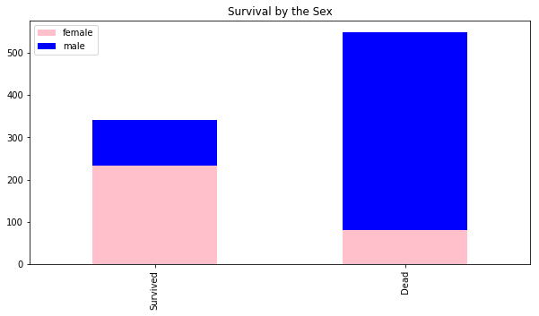

```python
survived_sex = train_df[train_df['Survived']==1]['Sex'].value_counts()
dead_sex = train_df[train_df['Survived']==0]['Sex'].value_counts()
df = pd.DataFrame([survived_sex,dead_sex])
df.index = ['Survived','Dead']
df.plot(kind='bar',stacked=True, figsize=(10,5), color=['pink','blue'], title='Survival by the Sex')
```

```
Text(0.5,1,'Survival by Age')
```

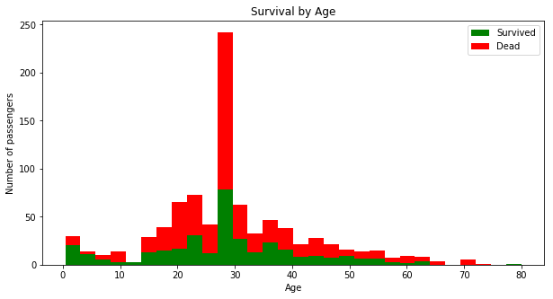

```python
df = train_df.copy()
df['Age'].fillna(df['Age'].median(), inplace=True)

figure = plt.figure(figsize=(10,5))
plt.hist([df[df['Survived']==1]['Age'],df[df['Survived']==0]['Age']],
         stacked=True, color = ['g','r'],
         bins = 30, label = ['Survived','Dead'])
plt.xlabel('Age')
plt.ylabel('Number of passengers')
plt.legend()
plt.title('Survival by Age')
```

```
Text(0.5,1,'Survival by Ticket Price')
```

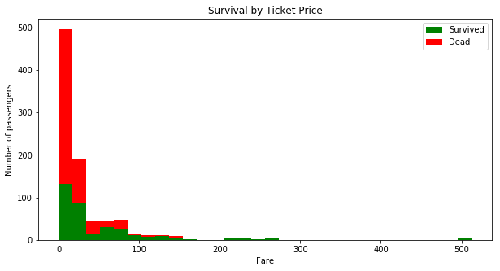

```python
df = train_df.copy()
df['Fare'].fillna(df['Fare'].median(), inplace=True)
figure = plt.figure(figsize=(10,5))
plt.hist(
            [df[df['Survived']==1]['Fare'],
            df[df['Survived']==0]['Fare']],
            stacked=True, color = ['g','r'],
            bins = 30,
            label = ['Survived','Dead']
        )
plt.xlabel('Fare')
plt.ylabel('Number of passengers')
plt.legend()
plt.title('Survival by Ticket Price')
```

## 3. 데이터 정제

### 3.1 Null값 처리.

```python
train_df.isnull().sum().sort_values(ascending=False)
```

```
Cabin          687
Age            177
Embarked         2
Fare             0
Ticket           0
Parch            0
SibSp            0
Sex              0
Name             0
Pclass           0
Survived         0
PassengerId      0
dtype: int64
```

```python
test_df.isnull().sum().sort_values(ascending=False)
```

```
Cabin          327
Age             86
Fare             1
Embarked         0
Ticket           0
Parch            0
SibSp            0
Sex              0
Name             0
Pclass           0
PassengerId      0
dtype: int64
```

```python
del train_df['Cabin']
# del train_df['Name']
# del train_df['PassengerId']
del train_df['Ticket']
del test_df['Cabin']
# del test_df['Name']
# del test_df['PassengerId']
del test_df['Ticket']

train_df=train_df.dropna(subset = ['Embarked'])
test_df=test_df.dropna(subset = ['Embarked'])
```

```python
train_df['Fare'].fillna(train_df['Fare'].median(), inplace=True)
train_df['Age'].fillna(train_df['Age'].median(), inplace=True)
test_df['Fare'].fillna(train_df['Fare'].median(), inplace=True)
test_df['Age'].fillna(train_df['Age'].median(), inplace=True)
```

```python
train_df.info()
```

```
<class 'pandas.core.frame.DataFrame'>
Int64Index: 889 entries, 0 to 890
Data columns (total 10 columns):
PassengerId    889 non-null int64
Survived       889 non-null int64
Pclass         889 non-null int64
Name           889 non-null object
Sex            889 non-null object
Age            889 non-null float64
SibSp          889 non-null int64
Parch          889 non-null int64
Fare           889 non-null float64
Embarked       889 non-null object
dtypes: float64(2), int64(5), object(3)
memory usage: 76.4+ KB
```

```python
train_df.isnull().sum().sort_values(ascending=False)
```

```
Embarked       0
Fare           0
Parch          0
SibSp          0
Age            0
Sex            0
Name           0
Pclass         0
Survived       0
PassengerId    0
dtype: int64
```

### 3.2 zero variance 처리

```python
train_df['Title'] = train_df['Name'].str.split(", ", expand=True)[1].str.split(".", expand=True)[0]
test_df['Title'] = test_df['Name'].str.split(", ", expand=True)[1].str.split(".", expand=True)[0]
```

```python
train_df['Title'].value_counts()
```

```
Mr              517
Miss            181
Mrs             124
Master           40
Dr                7
Rev               6
Col               2
Mlle              2
Major             2
Ms                1
Mme               1
Jonkheer          1
Sir               1
Capt              1
the Countess      1
Lady              1
Don               1
Name: Title, dtype: int64
```

```python
test_df['Title'].value_counts()
```

```
Mr        240
Miss       78
Mrs        72
Master     21
Col         2
Rev         2
Ms          1
Dr          1
Dona        1
Name: Title, dtype: int64
```

```python
for i in range(len(test_df)):
    if test_df.loc[i,'Title'] not in list(set(list(train_df['Title']))):
        test_df.loc[i,'Title'] ='Don'
```

```python
titles = (train_df['Title'].value_counts() < 10)
train_df['Title'] = train_df['Title'].apply(lambda x: 'other' if titles.loc[x] == True else x)
test_df['Title'] = test_df['Title'].apply(lambda x: 'other' if titles.loc[x] == True else x)

train_df['Title'].value_counts()
```

```
Mr        517
Miss      181
Mrs       124
Master     40
other      27
Name: Title, dtype: int64
```

```python
test_df['Title'].value_counts()
```

```
Mr        240
Miss       78
Mrs        72
Master     21
other       7
Name: Title, dtype: int64
```

```python
del train_df['Name']
del test_df['Name']
```

```python
train_df.head()
```

|  | PassengerId | Survived | Pclass | Sex | Age | SibSp | Parch | Fare | Embarked | Title |
| --- | --- | --- | --- | --- | --- | --- | --- | --- | --- | --- |
| 0 | 1 | 0 | 3 | male | 22.0 | 1 | 0 | 7.2500 | S | Mr |
| 1 | 2 | 1 | 1 | female | 38.0 | 1 | 0 | 71.2833 | C | Mrs |
| 2 | 3 | 1 | 3 | female | 26.0 | 0 | 0 | 7.9250 | S | Miss |
| 3 | 4 | 1 | 1 | female | 35.0 | 1 | 0 | 53.1000 | S | Mrs |
| 4 | 5 | 0 | 3 | male | 35.0 | 0 | 0 | 8.0500 | S | Mr |

```python
train_df.info()
```

```
<class 'pandas.core.frame.DataFrame'>
Int64Index: 889 entries, 0 to 890
Data columns (total 10 columns):
PassengerId    889 non-null int64
Survived       889 non-null int64
Pclass         889 non-null int64
Sex            889 non-null object
Age            889 non-null float64
SibSp          889 non-null int64
Parch          889 non-null int64
Fare           889 non-null float64
Embarked       889 non-null object
Title          889 non-null object
dtypes: float64(2), int64(5), object(3)
memory usage: 76.4+ KB
```

### 3.3 one-hot-coding

```python
train_dummies = pd.get_dummies(train_df)
test_dummies = pd.get_dummies(test_df)
```

```python
train_dummies.info()
```

```
<class 'pandas.core.frame.DataFrame'>
Int64Index: 889 entries, 0 to 890
Data columns (total 17 columns):
PassengerId     889 non-null int64
Survived        889 non-null int64
Pclass          889 non-null int64
Age             889 non-null float64
SibSp           889 non-null int64
Parch           889 non-null int64
Fare            889 non-null float64
Sex_female      889 non-null uint8
Sex_male        889 non-null uint8
Embarked_C      889 non-null uint8
Embarked_Q      889 non-null uint8
Embarked_S      889 non-null uint8
Title_Master    889 non-null uint8
Title_Miss      889 non-null uint8
Title_Mr        889 non-null uint8
Title_Mrs       889 non-null uint8
Title_other     889 non-null uint8
dtypes: float64(2), int64(5), uint8(10)
memory usage: 64.2 KB
```

```python
train_dummies.head()
```

|  | PassengerId | Survived | Pclass | Age | SibSp | Parch | Fare | Sex_female | Sex_male | Embarked_C | Embarked_Q | Embarked_S | Title_Master | Title_Miss | Title_Mr | Title_Mrs | Title_other |
| --- | --- | --- | --- | --- | --- | --- | --- | --- | --- | --- | --- | --- | --- | --- | --- | --- | --- |
| 0 | 1 | 0 | 3 | 22.0 | 1 | 0 | 7.2500 | 0 | 1 | 0 | 0 | 1 | 0 | 0 | 1 | 0 | 0 |
| 1 | 2 | 1 | 1 | 38.0 | 1 | 0 | 71.2833 | 1 | 0 | 1 | 0 | 0 | 0 | 0 | 0 | 1 | 0 |
| 2 | 3 | 1 | 3 | 26.0 | 0 | 0 | 7.9250 | 1 | 0 | 0 | 0 | 1 | 0 | 1 | 0 | 0 | 0 |
| 3 | 4 | 1 | 1 | 35.0 | 1 | 0 | 53.1000 | 1 | 0 | 0 | 0 | 1 | 0 | 0 | 0 | 1 | 0 |
| 4 | 5 | 0 | 3 | 35.0 | 0 | 0 | 8.0500 | 0 | 1 | 0 | 0 | 1 | 0 | 0 | 1 | 0 | 0 |

### 3.4 feature engineering

데이터를 충분한 시간 관찰 한 후에. 하도록 하겠습니다.

## 4.모형적용

### 4.1 Random Forest

```python
input_list = list(train_dummies.columns)
input_list.remove('Survived')
input_list.remove('PassengerId')
```

```python
input_list
```

```
['Pclass',
 'Age',
 'SibSp',
 'Parch',
 'Fare',
 'Sex_female',
 'Sex_male',
 'Embarked_C',
 'Embarked_Q',
 'Embarked_S',
 'Title_Master',
 'Title_Miss',
 'Title_Mr',
 'Title_Mrs',
 'Title_other']
```

```python
X_train = train_dummies[input_list]
Y_train = train_dummies['Survived']
X_test = test_dummies[input_list]
print(len(X_test))
# Y_test = test_dummies['Survived']
```

```
418
```

```python
sc_X = StandardScaler()
X_train = sc_X.fit_transform(X_train)
X_test = sc_X.transform(X_test)
```

```python
classifier = RandomForestClassifier(n_estimators = 80, criterion = 'entropy', max_depth = 6)
classifier.fit(X_train,Y_train)
```

```
RandomForestClassifier(bootstrap=True, class_weight=None, criterion='entropy',
            max_depth=6, max_features='auto', max_leaf_nodes=None,
            min_impurity_decrease=0.0, min_impurity_split=None,
            min_samples_leaf=1, min_samples_split=2,
            min_weight_fraction_leaf=0.0, n_estimators=80, n_jobs=1,
            oob_score=False, random_state=None, verbose=0,
            warm_start=False)
```

```python
Y_train_pred = classifier.predict(X_train)
Y_test_pred = classifier.predict(X_test)
```

## 5. 성능평가

### Random Forest

```python
confusion_matrix(Y_train, Y_train_pred)
```

```
array([[513,  36],
       [ 86, 254]])
```

```python
result = pd.DataFrame({'PassengerId' : test_dummies['PassengerId'],
                       'Survived' : Y_test_pred})
```

```python
result.to_csv('result.csv',index=False)
```